# data_wrangling_eda_nhanes

Noelia Caba Martin

2026-03-17

## Introduction

The National Health and Nutrition Examination Survey (NHANES) is a program of studies designed to assess the health and nutritional status of adults and children in the United States. The survey combines interviews and physical examinations and is conducted by the National Center for Health Statistics (NCHS).

This project demonstrates a complete data wrangling and exploratory data analysis (EDA) pipeline applied to real-world clinical data. Real-world datasets frequently contain missing values, outliers, inconsistent coding, and other data quality issues that must be addressed before any statistical analysis.

**Research question:** What are the demographic and clinical characteristics of the NHANES population, and what factors are associated with diabetes status?

The main objectives are:

- Perform data quality assessment and cleaning
- Handle missing values appropriately
- Identify and address outliers
- Conduct exploratory data analysis
- Perform biostatistical comparisons between diabetic and non-diabetic participants

## Setup

```r
library(NHANES)
library(naniar)
library(ggcorrplot)
library(tableone)
library(tidyverse)
library(ggplot2)
```

## Data Import and Initial Exploration

```r
# Load NHANES dataset
data(NHANES)

# Initial exploration
dim(NHANES)
```

```
## [1] 10000    76
```

```r
str(NHANES)
```

```
## tibble [10,000 × 76] (S3: tbl_df/tbl/data.frame)
##  $ ID              : int [1:10000] 51624 51624 51624 51625 51630 51638 51646 51647 51647 51647 ...
##  $ SurveyYr        : Factor w/ 2 levels "2009_10","2011_12": 1 1 1 1 1 1 1 1 1 1 ...
##  $ Gender          : Factor w/ 2 levels "female","male": 2 2 2 2 1 2 2 1 1 1 ...
##  $ Age             : int [1:10000] 34 34 34 4 49 9 8 45 45 45 ...
##  $ AgeDecade       : Factor w/ 8 levels " 0-9"," 10-19",..: 4 4 4 1 5 1 1 5 5 5 ...
##  $ AgeMonths       : int [1:10000] 409 409 409 49 596 115 101 541 541 541 ...
##  $ Race1           : Factor w/ 5 levels "Black","Hispanic",..: 4 4 4 5 4 4 4 4 4 4 ...
##  $ Race3           : Factor w/ 6 levels "Asian","Black",..: NA NA NA NA NA NA NA NA NA NA ...
##  $ Education       : Factor w/ 5 levels "8th Grade","9 - 11th Grade",..: 3 3 3 NA 4 NA NA 5 5 5 ...
##  $ MaritalStatus   : Factor w/ 6 levels "Divorced","LivePartner",..: 3 3 3 NA 2 NA NA 3 3 3 ...
##  $ HHIncome        : Factor w/ 12 levels " 0-4999"," 5000-9999",..: 6 6 6 5 7 11 9 11 11 11 ...
##  $ HHIncomeMid     : int [1:10000] 30000 30000 30000 22500 40000 87500 60000 87500 87500 87500 ...
##  $ Poverty         : num [1:10000] 1.36 1.36 1.36 1.07 1.91 1.84 2.33 5 5 5 ...
##  $ HomeRooms       : int [1:10000] 6 6 6 9 5 6 7 6 6 6 ...
```

[output cut: 62 more lines]

The NHANES dataset contains **10,000 observations** and **76 variables** covering demographic, clinical, laboratory, and lifestyle information.

For this analysis, we will focus on a subset of clinically relevant variables and use **diabetes status** as the primary grouping variable for biostatistical comparisons.

## Data Quality Assessment

Before cleaning the data, it is essential to assess the extent and pattern of missing values. Missing data is extremely common in real-world clinical datasets and must be handled appropriately to avoid biased results.

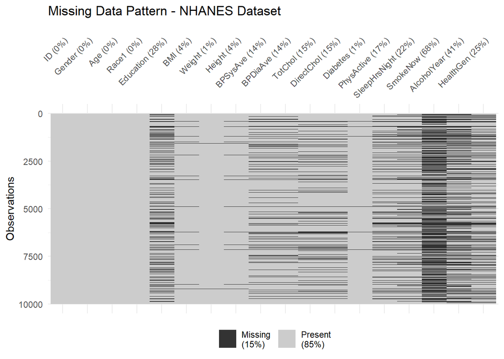

```r
# Select clinically relevant variables
nhanes_clean <- NHANES %>%
  select(ID, Gender, Age, Race1, Education, BMI,
         Weight, Height, BPSysAve, BPDiaAve,
         TotChol, DirectChol, Diabetes,
         PhysActive, SleepHrsNight, SmokeNow,
         AlcoholYear, HealthGen)

# Visualize missing data pattern
vis_miss(nhanes_clean) +
  labs(title = "Missing Data Pattern - NHANES Dataset") +
  theme(axis.text.x = element_text(angle = 45, hjust = 1))
```

```r
# Summary of missing values
miss_var_summary(nhanes_clean) %>%
  filter(n_miss > 0) %>%
  arrange(desc(pct_miss))
```

```
## # A tibble: 14 × 3
##    variable      n_miss pct_miss
##    <chr>          <int>    <num>
##  1 SmokeNow        6789    67.9
##  2 AlcoholYear     4078    40.8
##  3 Education       2779    27.8
##  4 HealthGen       2461    24.6
##  5 SleepHrsNight   2245    22.4
##  6 PhysActive      1674    16.7
##  7 TotChol         1526    15.3
##  8 DirectChol      1526    15.3
##  9 BPSysAve        1449    14.5
## 10 BPDiaAve        1449    14.5
## 11 BMI              366     3.66
## 12 Height           353     3.53
## 13 Diabetes         142     1.42
## 14 Weight            78     0.78
```

### Types of Missing Data

- **MCAR (Missing Completely At Random):** missingness is unrelated to any variable
- **MAR (Missing At Random):** missingness depends on observed variables
- **MNAR (Missing Not At Random):** missingness depends on the missing value itself (e.g., SmokeNow)

## Data Cleaning

Based on the missing data assessment, we will:

1. **Remove variables** with excessive missingness (SmokeNow, AlcoholYear)
2. **Filter complete cases** for key clinical variables
3. **Remove duplicate IDs** — the NHANES dataset contains repeated measurements for some participants
4. **Check and handle outliers** in continuous variables

```r
# Remove variables with excessive missingness and duplicates
nhanes_clean <- nhanes_clean %>%
  select(-SmokeNow, -AlcoholYear) %>%
  distinct(ID, .keep_all = TRUE) %>%
  filter(!is.na(Diabetes)) %>%
  filter(!is.na(BMI)) %>%
  filter(!is.na(BPSysAve)) %>%
  filter(!is.na(TotChol))

# Check dimensions after cleaning
dim(nhanes_clean)
```

```
## [1] 5197   16
```

```r
# Check remaining missing values
miss_var_summary(nhanes_clean) %>%
  filter(n_miss > 0)
```

```
## # A tibble: 4 × 3
##   variable      n_miss pct_miss
##   <chr>          <int>    <num>
## 1 Education       1015    19.5
## 2 HealthGen        687    13.2
## 3 SleepHrsNight    682    13.1
## 4 PhysActive       326     6.27
```

After cleaning, the dataset contains **5,197 participants** and **16 variables**. The cleaning steps removed:

- Duplicate participant IDs (repeated measurements)
- Participants with missing values in key clinical variables (Diabetes, BMI, Blood Pressure, Cholesterol)
- Variables with excessive missingness (SmokeNow, AlcoholYear)

Remaining missingness in Education (19.5%), HealthGen (13.2%), SleepHrsNight (13.1%), and PhysActive (6.3%) will be handled using complete case analysis for each specific analysis.

## Outlier Detection and Handling

Outliers are extreme values that may represent data entry errors, measurement errors, or genuinely unusual observations. In clinical data, it is important to distinguish between:

- **True outliers:** genuine extreme values that should be investigated
- **Data errors:** impossible or implausible values that should be removed

We will use **boxplots** and **the IQR method** to identify outliers in key continuous variables. A value is considered an outlier if it falls more than 1.5 × IQR below Q1 or above Q3.

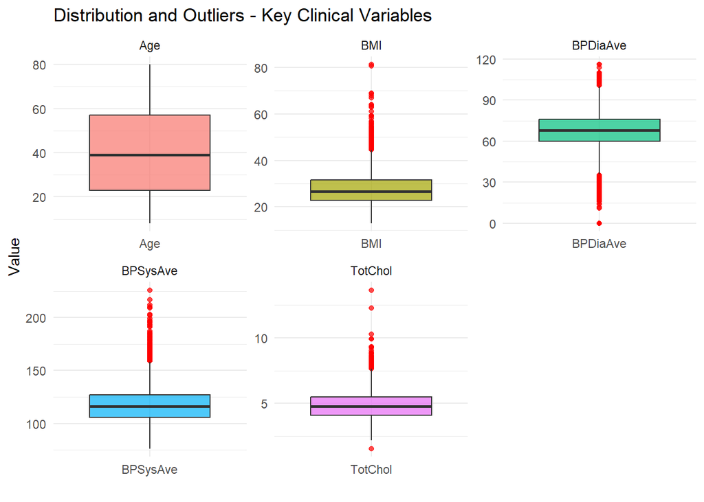

```r
# Visualize outliers in key continuous variables
nhanes_clean %>%
  select(BMI, BPSysAve, BPDiaAve, TotChol, Age) %>%
  pivot_longer(everything(), names_to = "variable", values_to = "value") %>%
  ggplot(aes(x = variable, y = value, fill = variable)) +
  geom_boxplot(alpha = 0.7, outlier.color = "red", outlier.size = 1.5) +
  facet_wrap(~variable, scales = "free") +
  theme_minimal() +
  theme(legend.position = "none") +
  labs(title = "Distribution and Outliers - Key Clinical Variables",
       x = "", y = "Value")
```

```r
# Count outliers using IQR method
outlier_count <- nhanes_clean %>%
  select(BMI, BPSysAve, BPDiaAve, TotChol) %>%
  summarise(across(everything(), ~sum(. > quantile(., 0.75, na.rm = TRUE) +
              1.5 * IQR(., na.rm = TRUE) |
              . < quantile(., 0.25, na.rm = TRUE) -
              1.5 * IQR(., na.rm = TRUE), na.rm = TRUE)))

outlier_count
```

```
## # A tibble: 1 × 4
##     BMI BPSysAve BPDiaAve TotChol
##   <int>    <int>    <int>   <int>
## 1   132      142      177      70
```

The IQR method identified outliers in all four key clinical variables:

- **BMI** (132 outliers): extreme values likely represent genuine obesity cases rather than data errors, as very high BMI values are clinically plausible
- **BPSysAve** (142 outliers): some extreme values may represent hypertensive crises or measurement errors
- **BPDiaAve** (177 outliers): values near zero are clinically implausible and likely represent measurement errors
- **TotChol** (70 outliers): extreme values may represent genuine hypercholesterolemia cases

Given that this is a population-based survey, most outliers likely represent genuine extreme values rather than errors. We will retain them for the analysis but note their presence as a limitation.

## Exploratory Data Analysis

With the data cleaned, we now perform a comprehensive exploratory data analysis to understand the distribution of variables and relationships between them, with a focus on differences between diabetic and non-diabetic participants.

### Diabetes Prevalence

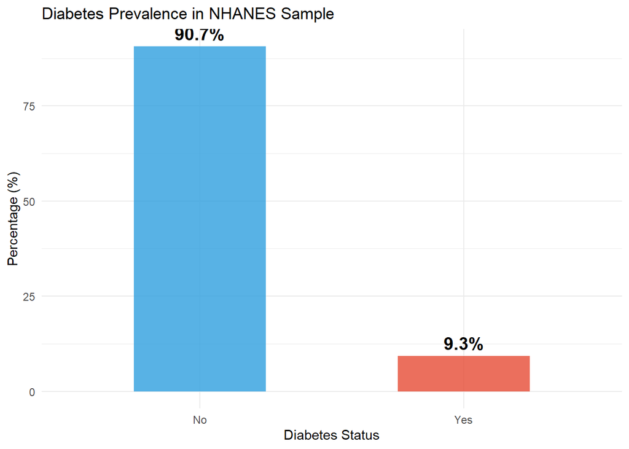

```r
# Diabetes prevalence
nhanes_clean %>%
  count(Diabetes) %>%
  mutate(pct = round(n / sum(n) * 100, 1)) %>%
  ggplot(aes(x = Diabetes, y = pct, fill = Diabetes)) +
  geom_col(width = 0.5, alpha = 0.8) +
  geom_text(aes(label = paste0(pct, "%")),
            vjust = -0.5, size = 5, fontface = "bold") +
  scale_fill_manual(values = c("No" = "#2E9FDF", "Yes" = "#E64B35")) +
  theme_minimal() +
  theme(legend.position = "none") +
  labs(title = "Diabetes Prevalence in NHANES Sample",
       x = "Diabetes Status", y = "Percentage (%)")
```

### Distribution of Clinical Variables by Diabetes Status

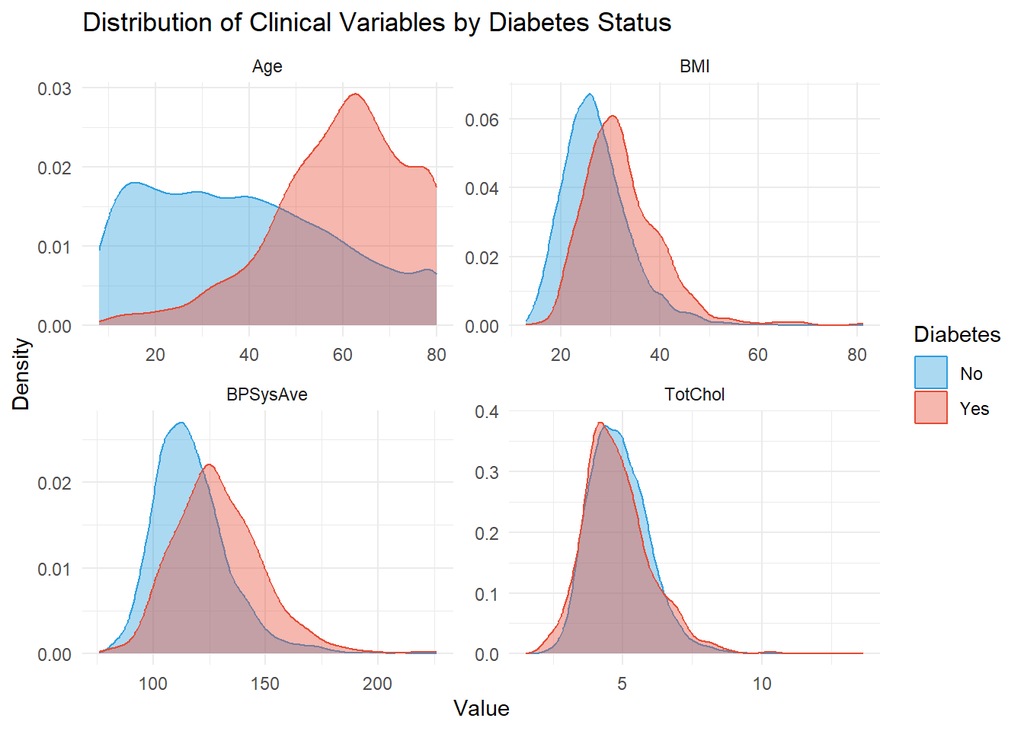

```r
# Distribution of continuous variables by diabetes status
nhanes_clean %>%
  select(Diabetes, Age, BMI, BPSysAve, TotChol) %>%
  pivot_longer(-Diabetes, names_to = "variable", values_to = "value") %>%
  ggplot(aes(x = value, fill = Diabetes, color = Diabetes)) +
  geom_density(alpha = 0.4) +
  facet_wrap(~variable, scales = "free") +
  scale_fill_manual(values = c("No" = "#2E9FDF", "Yes" = "#E64B35")) +
  scale_color_manual(values = c("No" = "#2E9FDF", "Yes" = "#E64B35")) +
  theme_minimal() +
  labs(title = "Distribution of Clinical Variables by Diabetes Status",
       x = "Value", y = "Density", fill = "Diabetes", color = "Diabetes")
```

The density plots reveal clear differences between diabetic and non-diabetic participants:

- **Age:** diabetic participants are substantially older, with the distribution shifted towards higher ages
- **BMI:** diabetic participants show higher BMI values, consistent with obesity as a major risk factor for type 2 diabetes
- **Systolic Blood Pressure:** diabetic participants tend to have slightly higher blood pressure, reflecting the common comorbidity of hypertension in diabetes
- **Total Cholesterol:** distributions largely overlap between groups, suggesting cholesterol alone may not be a strong discriminator

## Biostatistical Analysis

Having explored the data visually, we now perform formal biostatistical tests to quantify the differences between diabetic and non-diabetic participants.

### Table 1 - Baseline Characteristics

The “Table 1” is a standard element in clinical research papers. It summarizes the demographic and clinical characteristics of the study population, stratified by the main grouping variable, and includes p-values for between-group comparisons.

```r
# Define variables for Table 1
vars <- c("Age", "Gender", "BMI", "BPSysAve",
          "BPDiaAve", "TotChol", "PhysActive",
          "SleepHrsNight", "HealthGen")

# Define categorical variables
cat_vars <- c("Gender", "PhysActive", "HealthGen")

# Create Table 1
table1 <- CreateTableOne(
  vars = vars,
  strata = "Diabetes",
  data = nhanes_clean,
  factorVars = cat_vars
)

print(table1, showAllLevels = TRUE, formatOptions = list(big.mark = ","))
```

```
##                            Stratified by Diabetes
##                             level     No             Yes            p      test
##   n                                    4,712            485
##   Age (mean (SD))                      38.85 (20.08)  59.82 (14.45) <0.001
##   Gender (%)                female      2384 (50.6)     233 (48.0)   0.306
##                             male        2328 (49.4)     252 (52.0)
##   BMI (mean (SD))                      27.23 (6.82)   32.44 (7.95)  <0.001
##   BPSysAve (mean (SD))                116.99 (16.71) 129.06 (19.71) <0.001
##   BPDiaAve (mean (SD))                 66.83 (14.80)  68.29 (14.07)  0.037
##   TotChol (mean (SD))                   4.87 (1.06)    4.80 (1.18)   0.159
##   PhysActive (%)            No          1886 (43.0)     297 (61.4)  <0.001
##                             Yes         2501 (57.0)     187 (38.6)
##   SleepHrsNight (mean (SD))             6.93 (1.35)    6.76 (1.56)   0.010
##   HealthGen (%)             Excellent    497 (12.3)      21 ( 4.6)  <0.001
##                             Vgood       1357 (33.5)      65 (14.2)
##                             Good        1585 (39.1)     186 (40.7)
##                             Fair         539 (13.3)     136 (29.8)
##                             Poor          75 ( 1.9)      49 (10.7)
```

Table 1 reveals significant differences between diabetic and non-diabetic participants in most clinical variables:

- **Age** (p < 0.001): diabetic participants are on average 21 years older (59.82 vs 38.85 years)
- **BMI** (p < 0.001): diabetic participants have substantially higher BMI (32.44 vs 27.23 kg/m²)
- **Systolic Blood Pressure** (p < 0.001): diabetic participants show higher blood pressure (129.06 vs 116.99 mmHg)
- **Physical Activity** (p < 0.001): diabetic participants are less physically active (38.6% vs 57.0%)
- **General Health** (p < 0.001): diabetic participants report worse overall health status

Notably, **Gender** (p = 0.306) and **Total Cholesterol** (p = 0.159) did not differ significantly between groups.

## Correlation Analysis

A correlation matrix allows us to visualize the relationships between all continuous variables simultaneously. This helps identify potential multicollinearity and understand which variables are related to each other.

A correlation coefficient (r) ranges from -1 to 1:

- **r close to 1:** strong positive correlation
- **r close to -1:** strong negative correlation
- **r close to 0:** no linear relationship

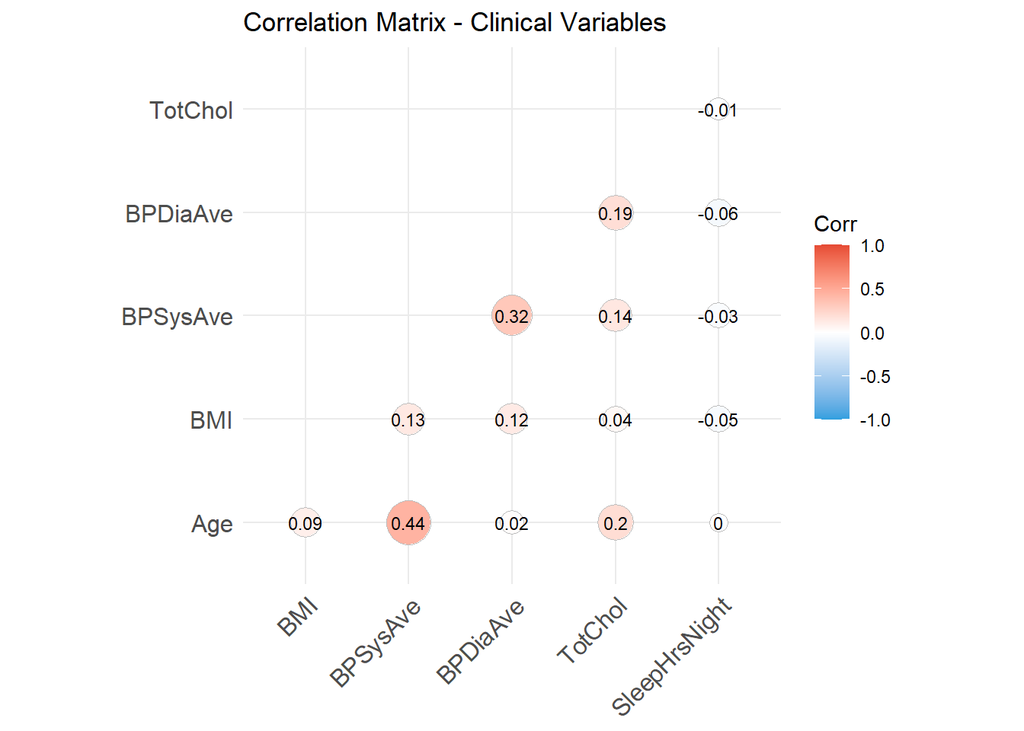

```r
# Select continuous variables
cor_data <- nhanes_clean  %>%
  select(Age, BMI, BPSysAve, BPDiaAve, TotChol, SleepHrsNight)  %>%
  cor(use = "complete.obs")

# Plot correlation matrix
ggcorrplot(cor_data,
  method = "circle",
  type = "lower",
  lab = TRUE,
  lab_size = 3,
  colors = c("#2E9FDF", "white", "#E64B35"),
  title = "Correlation Matrix - Clinical Variables",
  ggtheme = theme_minimal()
)
```

The correlation matrix reveals several clinically meaningful relationships:

- **Age and Systolic Blood Pressure** show the strongest correlation (r = 0.44), consistent with the well-established increase in blood pressure with aging
- **Systolic and Diastolic Blood Pressure** are moderately correlated (r = 0.32), as expected for two measures of the same physiological process
- **Age and Total Cholesterol** show a weak positive correlation (r = 0.20)
- **Sleep Hours** show no meaningful linear correlations with any clinical variable

Notably, no pairs show very high correlations (r > 0.7), suggesting absence of problematic multicollinearity among our variables.

## Conclusions

This analysis demonstrates a complete data wrangling and biostatistical analysis pipeline applied to real-world clinical data from the NHANES survey.

**Key findings:**

1. The raw NHANES dataset required substantial cleaning, including removal of duplicate IDs, variables with excessive missingness (SmokeNow: 67.9%, AlcoholYear: 40.8%), and participants with missing values in key clinical variables. The final dataset contained **5,197 participants**.
2. Diabetes prevalence in this sample was **9.3%**, consistent with reported US population estimates of approximately 10%.
3. Diabetic participants differed significantly from non-diabetic participants in age (59.82 vs 38.85 years, p < 0.001), BMI (32.44 vs 27.23 kg/m², p < 0.001), systolic blood pressure (129.06 vs 116.99 mmHg, p < 0.001), and physical activity levels (p < 0.001).
4. Gender and total cholesterol did not differ significantly between diabetic and non-diabetic participants.
5. Correlation analysis revealed age and systolic blood pressure as the most strongly correlated variables (r = 0.44), with no problematic multicollinearity detected.

**Limitations:**

- Complete case analysis was used for variables with moderate missingness, which may introduce bias if data are not missing at random
- Outliers were retained in the analysis as they likely represent genuine extreme values in a population survey
- Cross-sectional design prevents causal inference

**Future directions:**

- Apply multiple imputation for missing data handling
- Build a logistic regression model to predict diabetes status
- Investigate interaction effects between age, BMI and blood pressure